# Job_Placement

Brian Ellis

2023-02-24

```r
remove(list = ls())
library(tidyverse)
library(caret)
library(pROC)
library(glmnet)
```

```r
# Import dataset
Jobs <- read.csv("~/Downloads/Job_Placement_Data.csv")
head(Jobs)
```

```
##   gender ssc_percentage ssc_board hsc_percentage hsc_board hsc_subject
## 1      M          67.00    Others          91.00    Others    Commerce
## 2      M          79.33   Central          78.33    Others     Science
## 3      M          65.00   Central          68.00   Central        Arts
## 4      M          56.00   Central          52.00   Central     Science
## 5      M          85.80   Central          73.60   Central    Commerce
## 6      M          55.00    Others          49.80    Others     Science
##   degree_percentage undergrad_degree work_experience emp_test_percentage
## 1             58.00         Sci&Tech              No                55.0
## 2             77.48         Sci&Tech             Yes                86.5
## 3             64.00        Comm&Mgmt              No                75.0
## 4             52.00         Sci&Tech              No                66.0
## 5             73.30        Comm&Mgmt              No                96.8
## 6             67.25         Sci&Tech             Yes                55.0
##   specialisation mba_percent     status
## 1         Mkt&HR       58.80     Placed
## 2        Mkt&Fin       66.28     Placed
## 3        Mkt&Fin       57.80     Placed
## 4         Mkt&HR       59.43 Not Placed
## 5        Mkt&Fin       55.50     Placed
## 6        Mkt&Fin       51.58 Not Placed
```

## Introduction

The first question we must answer is which metrics we will use to judge fairness. Demographic parity, while nice in concept, doesn’t seem like the best metric to judge this dataset because it doesn’t take into account the quality of the candidate. We could satisfy demographic parity easily by selecting an equal proportion of males and females from the dataset with no regard for their merits as potential employees - this doesn’t seem like an ideal approach. A better approach would be to hire an equal proportion of males and females whom are qualified for the job. This leads us to equalized odds, which will be the focus of our project and the metric to which we will develop a new model to satisfy.

### Why equalized odds?

We are choosing to build a model that satisfies equalized odds to benefit the applicants in the dataset. Equalized odds will bring about similar true and false positive rates amongst males and females being hired. This is good news for the applicants as they can rest assured they are not being discriminated against based on any external factors.

### Why not predictive value parity?

Males and females in our dataset are not hired at equal rates and do not have equal measurements and statistics, as we will see in our exploratory data analysis. Predicitve value parity would benefit the employers hiring candidates but not necessarily the candidates.

## EDA

```r
str(Jobs)
```

```
## 'data.frame':    215 obs. of  13 variables:
##  $ gender             : chr  "M" "M" "M" "M" ...
##  $ ssc_percentage     : num  67 79.3 65 56 85.8 ...
##  $ ssc_board          : chr  "Others" "Central" "Central" "Central" ...
##  $ hsc_percentage     : num  91 78.3 68 52 73.6 ...
##  $ hsc_board          : chr  "Others" "Others" "Central" "Central" ...
##  $ hsc_subject        : chr  "Commerce" "Science" "Arts" "Science" ...
##  $ degree_percentage  : num  58 77.5 64 52 73.3 ...
##  $ undergrad_degree   : chr  "Sci&Tech" "Sci&Tech" "Comm&Mgmt" "Sci&Tech" ...
##  $ work_experience    : chr  "No" "Yes" "No" "No" ...
##  $ emp_test_percentage: num  55 86.5 75 66 96.8 ...
##  $ specialisation     : chr  "Mkt&HR" "Mkt&Fin" "Mkt&Fin" "Mkt&HR" ...
##  $ mba_percent        : num  58.8 66.3 57.8 59.4 55.5 ...
##  $ status             : chr  "Placed" "Placed" "Placed" "Not Placed" ...
```

```r
Jobs %>%
  group_by(gender) %>%
  summarize(count = n())
```

```
## # A tibble: 2 × 2
##   gender count
##   <chr>  <int>
## 1 F         76
## 2 M        139
```

We see a greater amount of males are present in the dataset. This will be important for us when considering base rates for job placement.

```r
Jobs %>%
  group_by(gender) %>%
  summarize(Count = n(),
            Placed = sum(status == "Placed"),
            Not_Placed = sum(status == "Not Placed"))
```

```
## # A tibble: 2 × 4
##   gender Count Placed Not_Placed
##   <chr>  <int>  <int>      <int>
## 1 F         76     48         28
## 2 M        139    100         39
```

Here we see the disparity between rates of placement of males and females in the dataset. We can see this more clearly by calculating the proportion of each gender that was placed.

```r
# Proportion of males and females placed
Jobs %>%
  count(gender, status) %>%
  group_by(gender) %>%
  summarize(status = status, prop = n / sum(n))
```

```
## # A tibble: 4 × 3
## # Groups:   gender [2]
##   gender status      prop
##   <chr>  <chr>      <dbl>
## 1 F      Not Placed 0.368
## 2 F      Placed     0.632
## 3 M      Not Placed 0.281
## 4 M      Placed     0.719
```

72% of male applicants were placed, while only 63% of female applicants ended up being placed. We can do a quick demographic parity check:
$$\frac {FemalesPlaced}{Males Placed}
= \frac{0.6315789}{0.7194245} = 0.87789$$

This leads to a demographic parity value of roughly 0.878 which is not bad but not great either. Our goal is not to satisfy demographic parity anyways but it’s good to see where this dataset lies with respect to it and this also shows how females in the dataset are in the minority class by a noticeable difference.

```r
Jobs %>%
  group_by(gender, undergrad_degree) %>%
  summarize(N = n())
```

```
## # A tibble: 6 × 3
## # Groups:   gender [2]
##   gender undergrad_degree     N
##   <chr>  <chr>            <int>
## 1 F      Comm&Mgmt           53
## 2 F      Others               6
## 3 F      Sci&Tech            17
## 4 M      Comm&Mgmt           92
## 5 M      Others               5
## 6 M      Sci&Tech            42
```

```r
# Calculate proportion of each gender in each degree type
JobProp <-
  Jobs %>%
    count(gender, undergrad_degree) %>%
    group_by(gender) %>%
    mutate(proportion = n / sum(n))
JobProp
```

```
## # A tibble: 6 × 4
## # Groups:   gender [2]
##   gender undergrad_degree     n proportion
##   <chr>  <chr>            <int>      <dbl>
## 1 F      Comm&Mgmt           53     0.697
## 2 F      Others               6     0.0789
## 3 F      Sci&Tech            17     0.224
## 4 M      Comm&Mgmt           92     0.662
## 5 M      Others               5     0.0360
## 6 M      Sci&Tech            42     0.302
```

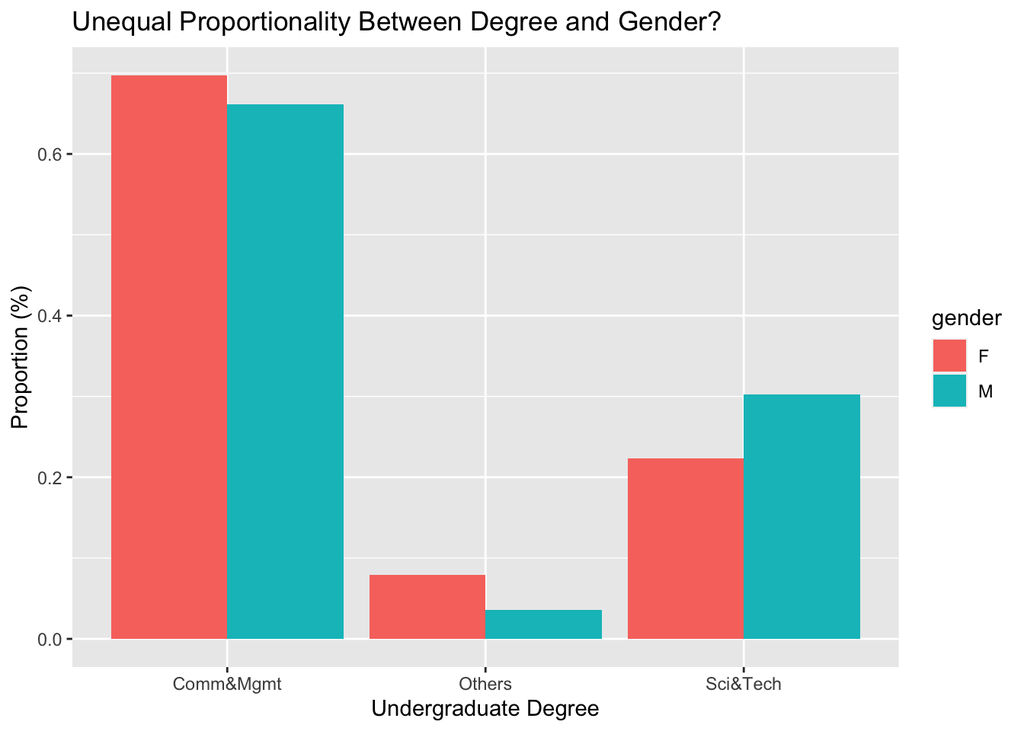

```r
# Visualize proportions to see if there's disparity
JobProp %>%
  ggplot(aes(x = undergrad_degree, y = proportion, group = gender, fill = gender)) +
  geom_bar(position='dodge', stat='identity') +
  labs(x = "Undergraduate Degree",
       y = "Proportion (%)",
       title = "Unequal Proportionality Between Degree and Gender?")
```

Here we see gender disparity between sexes in the type of undergraduate degree they pursued. A greater proportion of males graduated with ‘Sci&Tech’ degrees while a greater proportion of females graduated with ’Comm&Mgmt& degrees. We can test to see if these results are statistically significant.

```r
# Split proportions by gender to compare
DegreeFem <-
  Jobs %>%
  filter(gender == "F") %>%
  group_by(gender, undergrad_degree) %>%
  summarise(count = n())
DegreeMale <-
  Jobs %>%
  filter(gender == "M") %>%
  group_by(gender, undergrad_degree) %>%
  summarise(count = n())
chisq.test(DegreeFem$count, DegreeMale$count)
```

```
##
##  Pearson's Chi-squared test
##
## data:  DegreeFem$count and DegreeMale$count
## X-squared = 6, df = 4, p-value = 0.1991
```

We don’t see a statistically significant result when comparing males and females to undergraduate degree type.

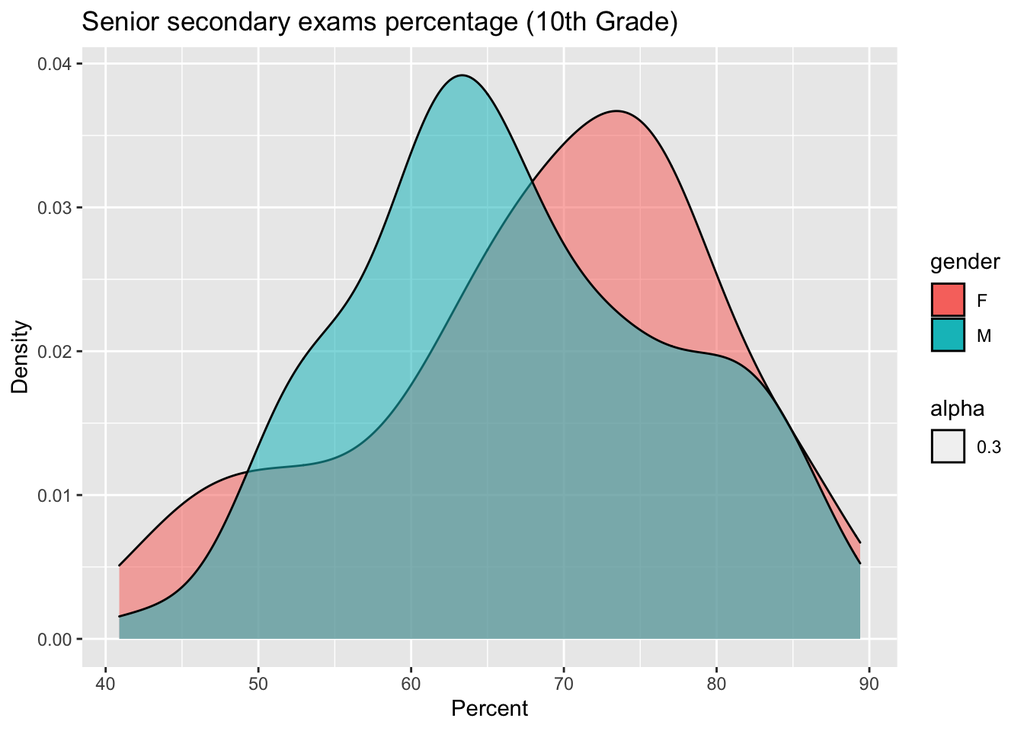

```r
# Visualize distributions of test scores across gender
Jobs %>%
  ggplot(aes(x = ssc_percentage, group = gender, fill = gender, alpha = 0.3)) +
  geom_density() +
  labs(title = "Senior secondary exams percentage (10th Grade)",
       x = "Percent",
       y = "Density")
```

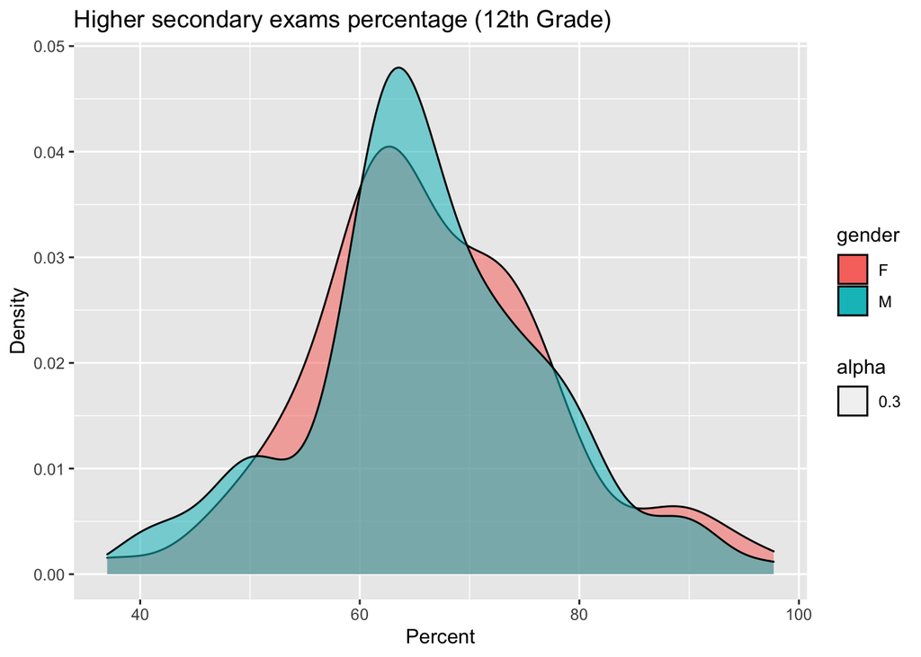

```r
Jobs %>%
  ggplot(aes(x = hsc_percentage, group = gender, fill = gender, alpha = 0.3)) +
  geom_density() +
  labs(title = "Higher secondary exams percentage (12th Grade)",
       x = "Percent",
       y = "Density")
```

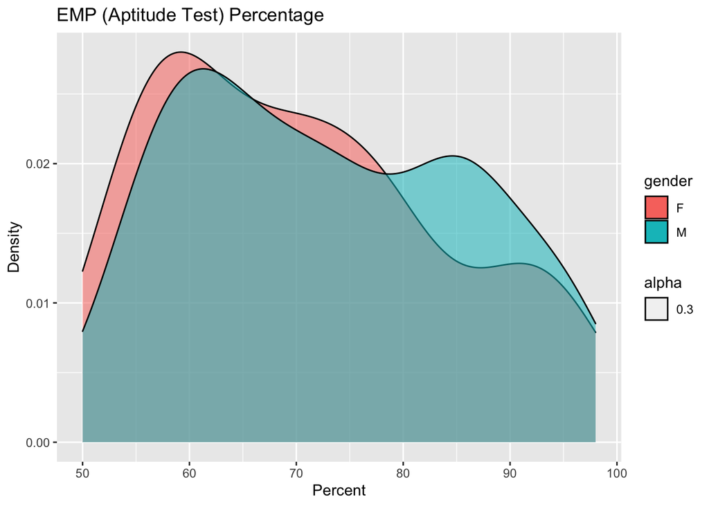

```r
Jobs %>%
  ggplot(aes(x = emp_test_percentage, group = gender, fill = gender, alpha = 0.3)) +
  geom_density() +
  labs(title = "EMP (Aptitude Test) Percentage",
       x = "Percent",
       y = "Density")
```

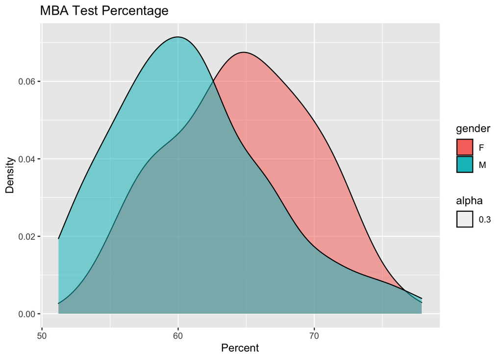

```r
Jobs %>%
  ggplot(aes(x = mba_percent, group = gender, fill = gender, alpha = 0.3)) +
  geom_density() +
  labs(title = "MBA Test Percentage",
       x = "Percent",
       y = "Density")
```

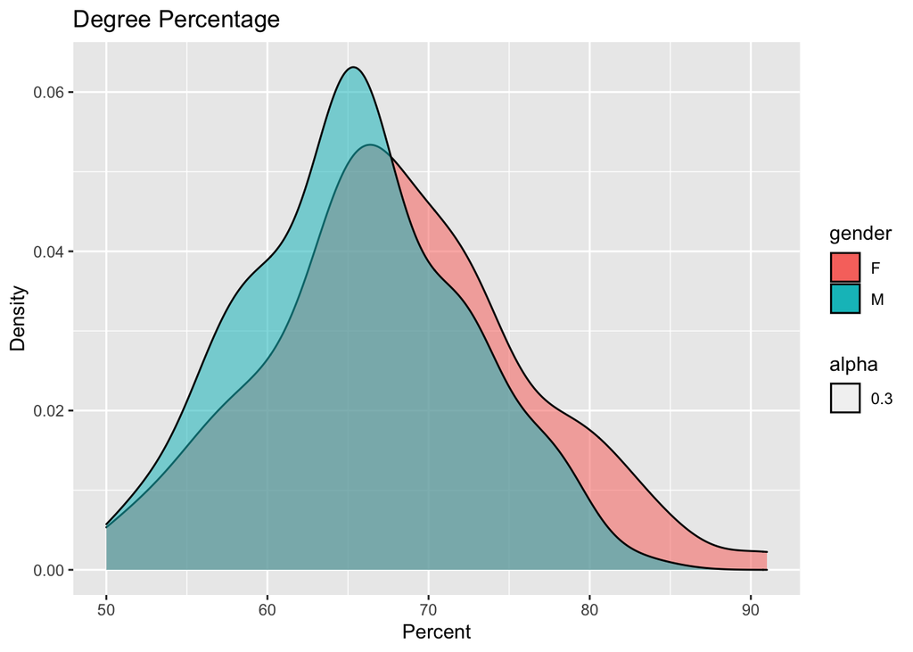

```r
Jobs %>%
  ggplot(aes(x = degree_percentage, group = gender, fill = gender, alpha = 0.3)) +
  geom_density() +
  labs(title = "Degree Percentage",
       x = "Percent",
       y = "Density")
```

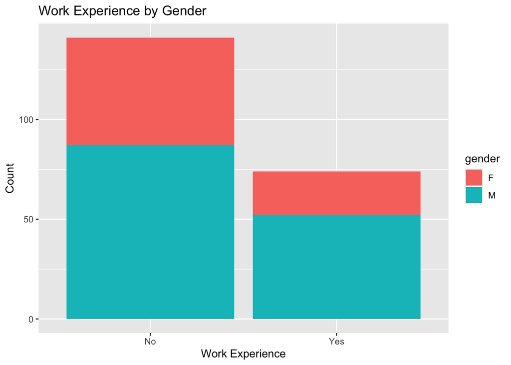

```r
Jobs %>%
  ggplot(aes(x = work_experience, fill = gender)) +
  geom_histogram(stat = "count") +
  labs(title = "Work Experience by Gender",
       x = "Work Experience",
       y = "Count")
```

```r
# Proportion of males and females with previous work experience
Jobs %>%
  count(gender, work_experience) %>%
  group_by(gender) %>%
  summarize(work_experience = work_experience,
            prop = n / sum(n))
```

```
## # A tibble: 4 × 3
## # Groups:   gender [2]
##   gender work_experience  prop
##   <chr>  <chr>           <dbl>
## 1 F      No              0.711
## 2 F      Yes             0.289
## 3 M      No              0.626
## 4 M      Yes             0.374
```

We can see a greater proportion of females don’t have previous work experience. This could factor into he decision maker’s process when selecting candidates to place into a job.

Now that we know roughly what our data looks like when comparing amongst genders, we can begin building some initial models to help us determine which features are most important and which ones to include in our final model.

## Model Exploration

```r
# Create indicator variable for response
Jobs <- Jobs %>%
  mutate(Placed = ifelse(status == "Placed", 1, 0))
# Inital log reg
genderlm <- lm(Placed ~ gender, data = Jobs)
summary(genderlm)
```

```
##
## Call:
## lm(formula = Placed ~ gender, data = Jobs)
##
## Residuals:
##     Min      1Q  Median      3Q     Max
## -0.7194 -0.6316  0.2806  0.2806  0.3684
##
## Coefficients:
##             Estimate Std. Error t value Pr(>|t|)
## (Intercept)  0.63158    0.05316  11.881   <2e-16 ***
## genderM      0.08785    0.06611   1.329    0.185
## ---
## Signif. codes:  0 '***' 0.001 '**' 0.01 '*' 0.05 '.' 0.1 ' ' 1
##
## Residual standard error: 0.4634 on 213 degrees of freedom
## Multiple R-squared:  0.008221,   Adjusted R-squared:  0.003565
## F-statistic: 1.766 on 1 and 213 DF,  p-value: 0.1853
```

This simple linear regression model has a positive coefficient associated with being male, when gender is the only variable being considered for job placement.

### Feature Selection

```r
# Indicator variables
Jobs <- Jobs %>%
  mutate(Placed = ifelse(status == "Placed", 1, 0))

#Build Intercept Only Model. NOTE: ~ 1 tells R that you only want an intercept
int_only_model <- glm(Placed ~ 1, family = binomial, data = Jobs)

#Build model with all potential regressors.
full_model <- glm(Placed ~ . -status, family = binomial, data = Jobs)

#Perform backward elimination
stats::step(object = full_model,
            scope = list(lower = int_only_model, upper = full_model),
            data = Train,
            direction = "backward")
```

```
## Start:  AIC=129.68
## Placed ~ (gender + ssc_percentage + ssc_board + hsc_percentage +
##     hsc_board + hsc_subject + degree_percentage + undergrad_degree +
##     work_experience + emp_test_percentage + specialisation +
##     mba_percent + status) - status
##
##                       Df Deviance    AIC
## - hsc_subject          2  101.327 127.33
## - ssc_board            1   99.778 127.78
## - hsc_board            1   99.879 127.88
## - specialisation       1   99.901 127.90
## - emp_test_percentage  1  100.069 128.07
## <none>                     99.677 129.68
## - gender               1  102.855 130.85
## - undergrad_degree     2  105.236 131.24
## - hsc_percentage       1  109.778 137.78
## - work_experience      1  110.159 138.16
## - degree_percentage    1  112.815 140.81
## - mba_percent          1  115.501 143.50
## - ssc_percentage       1  140.508 168.51
##
## Step:  AIC=127.33
## Placed ~ gender + ssc_percentage + ssc_board + hsc_percentage +
##     hsc_board + degree_percentage + undergrad_degree + work_experience +
##     emp_test_percentage + specialisation + mba_percent
##
##                       Df Deviance    AIC
## - ssc_board            1   101.42 125.42
## - specialisation       1   101.61 125.61
## - hsc_board            1   101.62 125.62
## - emp_test_percentage  1   101.78 125.78
## <none>                     101.33 127.33
## - gender               1   104.70 128.70
## - undergrad_degree     2   106.94 128.94
## - hsc_percentage       1   110.96 134.96
## - work_experience      1   114.02 138.02
## - degree_percentage    1   114.89 138.89
## - mba_percent          1   117.06 141.06
## - ssc_percentage       1   146.89 170.89
##
```

[output cut: 49 more lines]

```
## - ssc_percentage     1   151.47 169.47
##
## Step:  AIC=120.98
## Placed ~ gender + ssc_percentage + hsc_percentage + degree_percentage +
##     undergrad_degree + work_experience + mba_percent
##
##                     Df Deviance    AIC
## <none>                   102.98 120.98
## - undergrad_degree   2   108.78 122.78
## - gender             1   108.15 124.15
## - hsc_percentage     1   113.76 129.76
## - work_experience    1   116.94 132.94
## - degree_percentage  1   117.57 133.57
## - mba_percent        1   118.77 134.77
## - ssc_percentage     1   151.75 167.75
```

```
##
## Call:  glm(formula = Placed ~ gender + ssc_percentage + hsc_percentage +
##     degree_percentage + undergrad_degree + work_experience +
##     mba_percent, family = binomial, data = Jobs)
##
## Coefficients:
##              (Intercept)                   genderM            ssc_percentage
##                -20.89182                   1.37280                   0.22242
##           hsc_percentage         degree_percentage    undergrad_degreeOthers
##                  0.09953                   0.18706                  -0.47685
## undergrad_degreeSci&Tech        work_experienceYes               mba_percent
##                 -1.42573                   2.29036                  -0.19628
##
## Degrees of Freedom: 214 Total (i.e. Null);  206 Residual
## Null Deviance:       266.8
## Residual Deviance: 103   AIC: 121
```

From this backward feature selection, we can remove a few variables from our model. It also shows a positive value for ‘genderM’ which can indicate some gender bias in favor of males in the dataset.

We can also build a LASSO model and see what it deems are the most important features

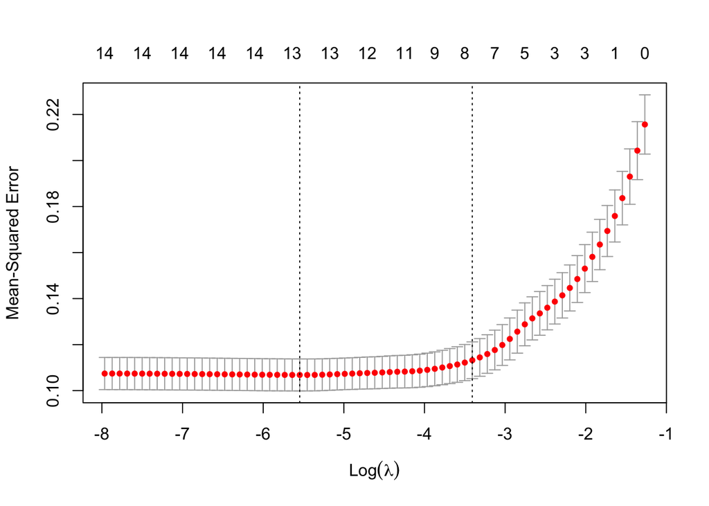

```r
#Put data frame in form needed for glmnet
Xmat <- model.matrix(Placed ~ . -status, data = Jobs)[ ,-1]
y <- Jobs$Placed
# Build LASSO model
set.seed(42)
cv.out <- cv.glmnet(x = Xmat, y = y,
                    alpha = 1, standardize = TRUE,
                    nfolds = 10)
set.seed(NULL)
plot(cv.out)
```

Let’s select the largest lambda value within 1 standard deviation of the minimum. This will provide us with a lambda value that will apply more regularization and thus narrow down our features to only the most important.

```r
bestlam1 <- cv.out$lambda.1se
#Predict the responses for the test set (use for MSE/RMSE calc)
lasso.pred1 <- predict(cv.out , s = bestlam1,
                      newx = Xmat)
#Find the coefficients
lasso.coef1 <- predict(cv.out , s = bestlam1,
                      type = "coefficients")
bestlam1
```

```
## [1] 0.03313302
```

```r
lasso.coef1
```

```
## 15 x 1 sparse Matrix of class "dgCMatrix"
##                                    s1
## (Intercept)              -0.954296636
## genderM                   0.023097446
## ssc_percentage            0.016929809
## ssc_boardOthers           .
## hsc_percentage            0.007535548
## hsc_boardOthers           .
## hsc_subjectCommerce       .
## hsc_subjectScience        .
## degree_percentage         0.010400013
## undergrad_degreeOthers    .
## undergrad_degreeSci&Tech -0.011951277
## work_experienceYes        0.106620309
## emp_test_percentage       .
## specialisationMkt&HR     -0.022013285
## mba_percent              -0.011649280
```

This lambda value applies a lot of regularization which allows us to see the most important variables when it comes to a candidate being placed.

We’ll now build a model containing only the selected features of ssc_percentage, mba_percent, and degree_percentage.

```r
log_reg <- glm(Placed ~ gender + ssc_percentage + mba_percent + degree_percentage, family = "binomial", data = Jobs)
summary(log_reg)
```

```
##
## Call:
## glm(formula = Placed ~ gender + ssc_percentage + mba_percent +
##     degree_percentage, family = "binomial", data = Jobs)
##
## Deviance Residuals:
##     Min       1Q   Median       3Q      Max
## -2.4705  -0.2697   0.1592   0.5125   2.1390
##
## Coefficients:
##                    Estimate Std. Error z value Pr(>|z|)
## (Intercept)       -16.60414    3.70744  -4.479 7.51e-06 ***
## genderM             1.30837    0.52868   2.475  0.01333 *
## ssc_percentage      0.21120    0.03511   6.015 1.79e-09 ***
## mba_percent        -0.13051    0.04319  -3.022  0.00251 **
## degree_percentage   0.16999    0.04113   4.133 3.58e-05 ***
## ---
## Signif. codes:  0 '***' 0.001 '**' 0.01 '*' 0.05 '.' 0.1 ' ' 1
##
## (Dispersion parameter for binomial family taken to be 1)
##
##     Null deviance: 266.77  on 214  degrees of freedom
## Residual deviance: 135.93  on 210  degrees of freedom
## AIC: 145.93
##
## Number of Fisher Scoring iterations: 6
```

The gender coefficient has a positive value associated with being male and is statistically signficant with a p-value of less than 0.05. We can deduce that if a candidate is male, i.e., has a value of 1 for their gender variable, then their odds of being hired are
$$e^{1.30837} \approx 3.7$$
times the odds of being hired if they were female.

Let’s visualize these features with respect to gender.

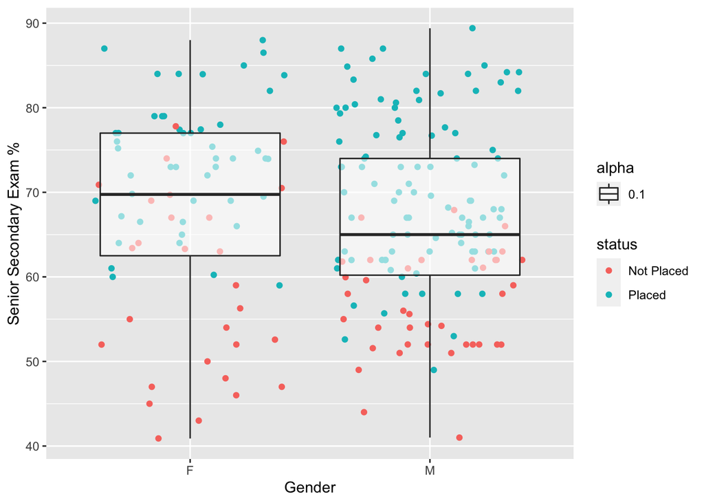

```r
# Reload dataset
Jobs <- read.csv("~/Downloads/Job_Placement_Data.csv")
# Relationship between gender and ssc_percentage
Jobs %>%
  ggplot(aes(x = gender, y = ssc_percentage)) +
  geom_point(aes(color = status), position = "jitter") +
  geom_boxplot(aes(alpha = 0.1)) +
  labs(x = "Gender",
       y = "Senior Secondary Exam %")
```

Even though Females scored higher overall ssc_percentage, males were still hired at a greater rate. This shows gender is a greater predictor for placement as compared with ssc_percentage, a variable we originally thought of as the most important.

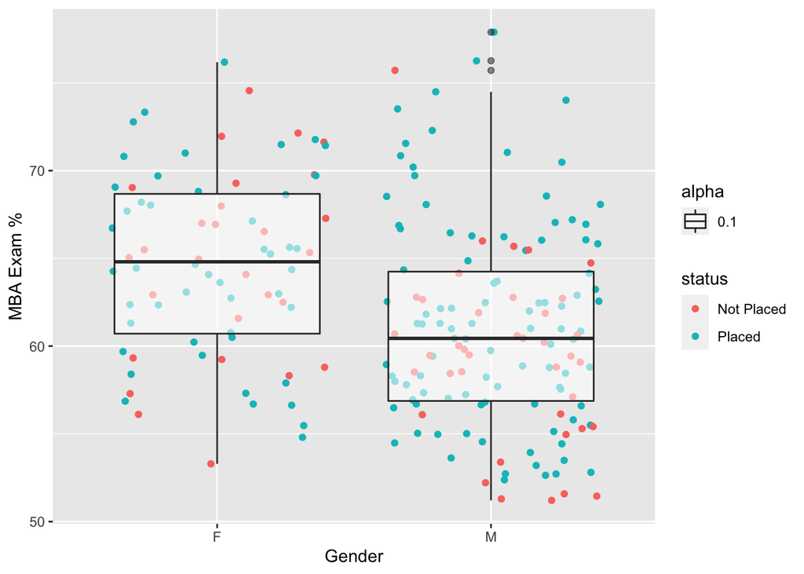

```r
# Relationship between gender and ssc_percentage
Jobs %>%
  ggplot(aes(x = gender, y = mba_percent)) +
  geom_point(aes(color = status), position = "jitter") +
  geom_boxplot(aes(alpha = 0.1)) +
  labs(x = "Gender",
       y = "MBA Exam %")
```

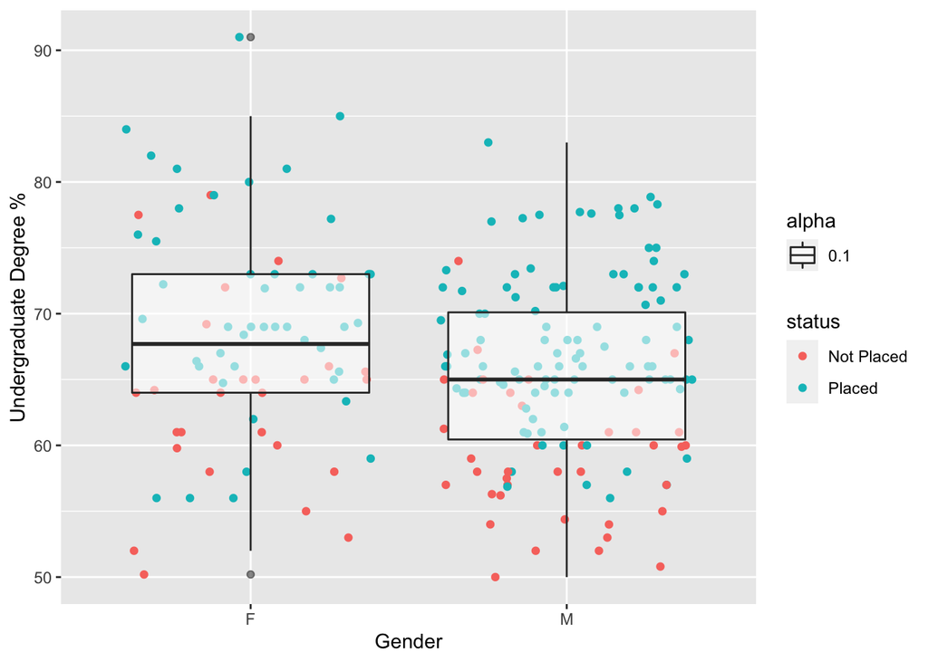

```r
Jobs %>%
  ggplot(aes(x = gender, y = degree_percentage)) +
  geom_point(aes(color = status), position = "jitter") +
  geom_boxplot(aes(alpha = 0.1)) +
  labs(x = "Gender",
       y = "Undergraduate Degree %")
```

For all these variables that are important for the placement, females have a higher overall score. So why do males have a higher job placement probability than females?

Let’s use our logistic regression model to predict the probability that 2 new candidates will get hired. These two candidates will have the same attributes across variables, (same exam scores and degree percentage), with the only difference being the gender of the applicant. For the other attributes, we’ll use the median value of male applicants.

```r
Female_prob <- predict(log_reg, newdata = data.frame(gender = 'F', ssc_percentage = 65, mba_percent = 61, degree_percentage = 65), type = "response")
Male_prob <- predict(log_reg, newdata = data.frame(gender = 'M', ssc_percentage = 65, mba_percent = 61, degree_percentage = 65), type = "response")

cat("Female Probability:", Female_prob)
```

```
## Female Probability: 0.5527572
```

```r
cat("\nMale Probability:  ", Male_prob)
```

```
##
## Male Probability:   0.8205662
```

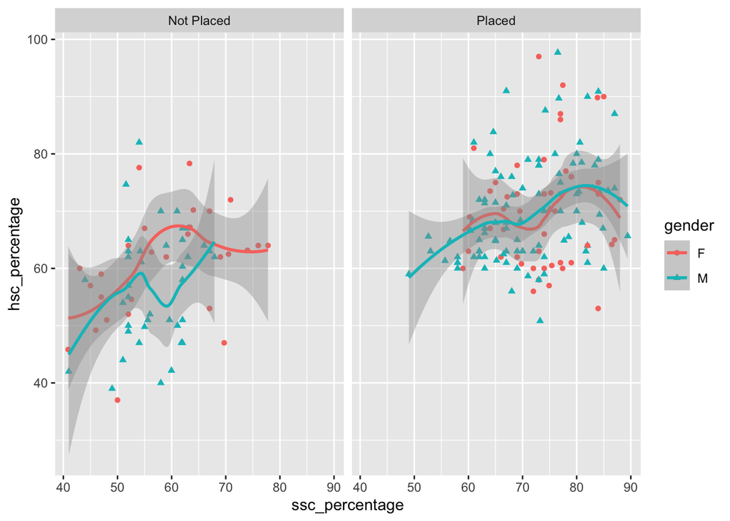

```r
Jobs %>%
  ggplot(aes(x = ssc_percentage, y = hsc_percentage, color = gender, shape = gender)) +
  geom_point() +
  geom_smooth() +
  facet_wrap(~ status)
```

We can see that there are a greater number of poor performing male candidates bringing the average exam percentages down for the male group. If we look at the distribution between placed members of each gender group, we get a more balanced distribution between gender and exam scores.

## Equalized Odds

```r
# Create indicator variables
Jobs <- Jobs %>%
  mutate(Placed = ifelse(status == "Placed", 1, 0))
xvars <- c("ssc_percentage", "mba_percent", "degree_percentage")
# Scale
Jobs[, xvars] <- scale(Jobs[ , xvars], center = TRUE, scale = TRUE)
```

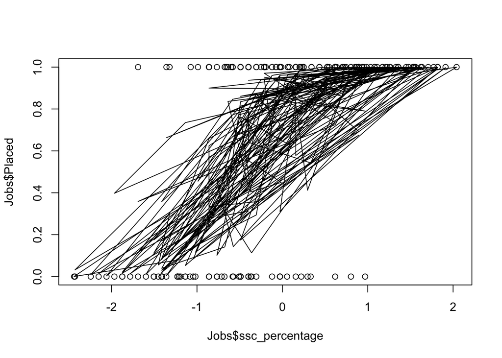

```r
plot(x = Jobs$ssc_percentage, y = Jobs$Placed)

glm.fit = glm(Placed ~ ssc_percentage + mba_percent + degree_percentage + gender, family = binomial, data = Jobs)
lines(Jobs$ssc_percentage, glm.fit$fitted.values)
```

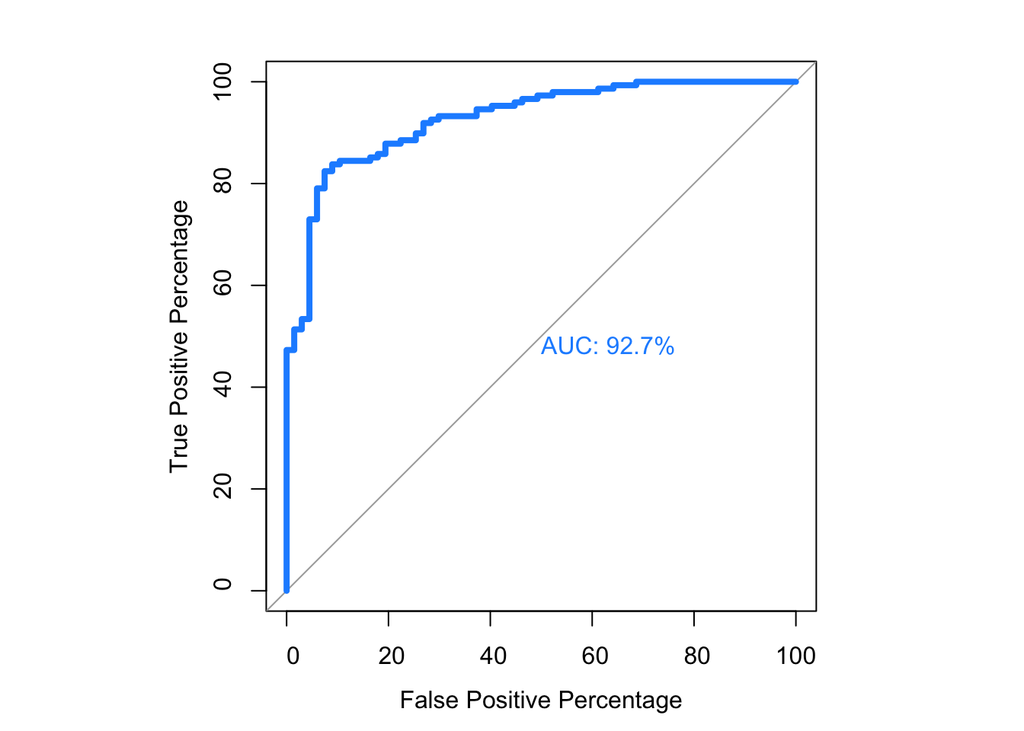

```
##
## Call:
## roc.default(response = Jobs$Placed, predictor = glm.fit$fitted.values,     percent = T, plot = T, legacy.axes = T, xlab = "False Positive Percentage",     ylab = "True Positive Percentage", col = "dodgerblue", lwd = 4,     print.auc = T)
##
## Data: glm.fit$fitted.values in 67 controls (Jobs$Placed 0) < 148 cases (Jobs$Placed 1).
## Area under the curve: 92.75%
```

```r
# set boundaries to square
par(pty = "s")
# Plot ROC curve
roc(Jobs$Placed, glm.fit$fitted.values, plot = T, legacy.axes = T, percent = T,
    xlab = "False Positive Percentage", ylab = "True Positive Percentage",
    col = "dodgerblue", lwd = 4, print.auc = T)
```

```r
# Obtain thresholds from ROC curve
roc.info <- roc(Jobs$Placed, glm.fit$fitted.values, legacy.axes = T)

roc.df <- data.frame(
  tpp = roc.info$sensitivities * 100,
  fpp = (1 - roc.info$sensitivities) * 100,
  thresholds = roc.info$thresholds
)
head(roc.df)
```

```
##   tpp fpp  thresholds
## 1 100   0        -Inf
## 2 100   0 0.001913334
## 3 100   0 0.003689650
## 4 100   0 0.006624993
## 5 100   0 0.009918556
## 6 100   0 0.012079586
```

```r
tail(roc.df)
```

```
##           tpp       fpp thresholds
## 211 3.3783784  96.62162  0.9988886
## 212 2.7027027  97.29730  0.9991208
## 213 2.0270270  97.97297  0.9993116
## 214 1.3513514  98.64865  0.9994313
## 215 0.6756757  99.32432  0.9995625
## 216 0.0000000 100.00000        Inf
```

```r
# Append fitted values into data
glm.fit$data <- glm.fit$data %>%
  mutate(values = glm.fit$fitted.values)

# Create male and female datasets
Males <- glm.fit$data %>%
  filter(gender == "M")

Females <- glm.fit$data %>%
  filter(gender == "F")

# Overlap ROC curves for males and females
par(pty = "s")
roc(Males$Placed, Males$values, plot = T, legacy.axes = T, percent = T,
    xlab = "False Positive Percentage", ylab = "True Positive Percentage",
    col = "dodgerblue", lwd = 4, print.auc = T)
```

```
##
## Call:
## roc.default(response = Males$Placed, predictor = Males$values,     percent = T, plot = T, legacy.axes = T, xlab = "False Positive Percentage",     ylab = "True Positive Percentage", col = "dodgerblue", lwd = 4,     print.auc = T)
##
## Data: Males$values in 39 controls (Males$Placed 0) < 100 cases (Males$Placed 1).
## Area under the curve: 94.28%
```

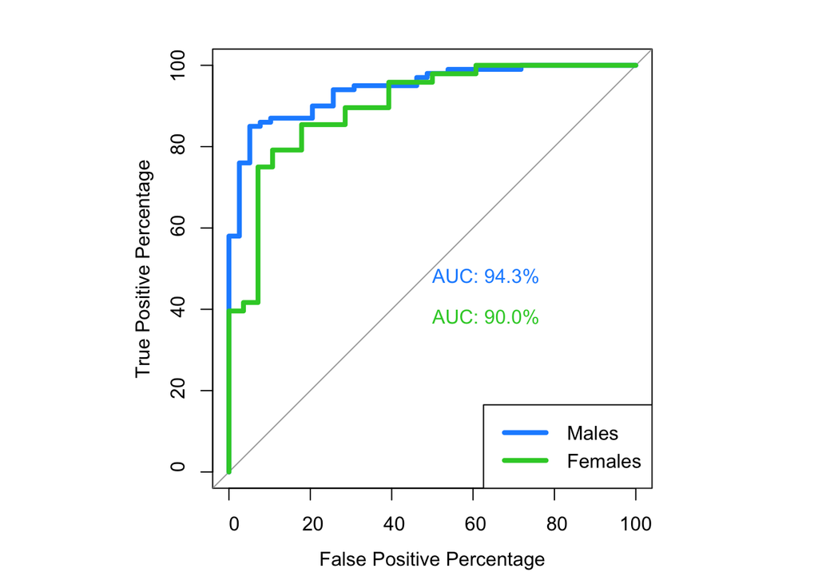

```r
plot.roc(Females$Placed, Females$values, add = T, percent = T,
    col = "limegreen", lwd = 4, print.auc = T, print.auc.y = 40)
legend("bottomright", legend = c("Males", "Females"), col = c("dodgerblue", "limegreen"), lwd = 4)
```

```r
# Set draw graph space back to default
par(pty = "m")
```

We see that Males have a greater AUC score than Females. We can isolate the areas where the ROC curves intersect to determine which thresholds for males and females would be ideal.

```r
# Obtain thresholds from ROC curve for Males and Females
roc_males.info <- roc(Males$Placed, Males$values, legacy.axes = T)
roc_males.df <- data.frame(
  tpp = roc_males.info$sensitivities * 100,
  fpp = (1 - roc_males.info$sensitivities) * 100,
  thresholds = roc_males.info$thresholds
)

roc_females.info <- roc(Females$Placed, Females$values, legacy.axes = T)
roc_females.df <- data.frame(
  tpp = roc_females.info$sensitivities * 100,
  fpp = (1 - roc_females.info$sensitivities) * 100,
  thresholds = roc_females.info$thresholds
)

# Isolate thresholds where TPP and FPP are optimal
roc_males.df[roc_males.df$tpp > 85 & roc_males.df$tpp < 95, ]
```

```
##    tpp fpp thresholds
## 34  94   6  0.4376947
## 35  94   6  0.4486050
## 36  94   6  0.4536262
## 37  93   7  0.4938150
## 38  92   8  0.5429397
## 39  91   9  0.5619735
## 40  90  10  0.5974606
## 41  90  10  0.6296903
## 42  90  10  0.6378965
## 43  89  11  0.6499897
## 44  88  12  0.6609593
## 45  87  13  0.6656897
## 46  87  13  0.6753344
## 47  87  13  0.6945425
## 48  87  13  0.7153849
## 49  87  13  0.7273644
## 50  86  14  0.7329066
## 51  86  14  0.7368982
```

```r
roc_females.df[roc_females.df$tpp > 85 & roc_females.df$tpp < 95, ]
```

```
##         tpp       fpp thresholds
## 21 93.75000  6.250000  0.3613213
## 22 91.66667  8.333333  0.3801470
## 23 89.58333 10.416667  0.3964242
## 24 89.58333 10.416667  0.4010937
## 25 89.58333 10.416667  0.4083623
## 26 89.58333 10.416667  0.4309319
## 27 87.50000 12.500000  0.4691016
## 28 85.41667 14.583333  0.5155683
## 29 85.41667 14.583333  0.5568196
## 30 85.41667 14.583333  0.5745357
## 31 85.41667 14.583333  0.5900092
```

We should be looking for threshold values for males and females where the true and false positive rates are similar. This occurs when Male and Female tpp is 89 and also when tpp is 94. The threshold for males and females for both of these tpp rates are 0.65 and 0.43, and 0.45 and 0.36 respectively.

This difference between threshold values indicates a discrepancy between the success rate of males and females in the dataset when considering ‘Placed’ as a successful outcome. When moving forward with our unbiased model, we should use either of these set of threshold values for males and females to achieve equalized odds.

```r
#Establish male threshold
male_thresh <- 0.65

#Establish female threshold
female_thresh <- 0.43

#Find predicted probabilities for all in dataset
male_prob <- predict(glm.fit, newdata = Males, type = "response")
female_prob <- predict(glm.fit, newdata = Females, type = "response")

#Predict placed
male_pred <- ifelse(male_prob > male_thresh, 1, 0)
female_pred <- ifelse(female_prob > female_thresh, 1, 0)

# Create confusion matrices
# Male matrix
male_matrix <- confusionMatrix(data = as.factor(male_pred),
                reference = as.factor(Males$Placed),
                positive = "1")

# Female matrix
female_matrix <- confusionMatrix(data = as.factor(female_pred),
                reference = as.factor(Females$Placed),
                positive = "1")

cat("Male confusion matrix:\n")
```

```
## Male confusion matrix:
```

```r
print(male_matrix)
```

```
## Confusion Matrix and Statistics
##
##           Reference
## Prediction  0  1
##          0 31 11
##          1  8 89
##
##                Accuracy : 0.8633
##                  95% CI : (0.7948, 0.9157)
##     No Information Rate : 0.7194
##     P-Value [Acc > NIR] : 4.335e-05
##
##                   Kappa : 0.6692
##
##  Mcnemar's Test P-Value : 0.6464
##
##             Sensitivity : 0.8900
##             Specificity : 0.7949
##          Pos Pred Value : 0.9175
##          Neg Pred Value : 0.7381
##              Prevalence : 0.7194
##          Detection Rate : 0.6403
##    Detection Prevalence : 0.6978
##       Balanced Accuracy : 0.8424
##
##        'Positive' Class : 1
##
```

```r
cat("Female confusion matrix:\n")
```

```
## Female confusion matrix:
```

```r
print(female_matrix)
```

```
## Confusion Matrix and Statistics
##
##           Reference
## Prediction  0  1
##          0 20  5
##          1  8 43
##
##                Accuracy : 0.8289
##                  95% CI : (0.7253, 0.9057)
##     No Information Rate : 0.6316
##     P-Value [Acc > NIR] : 0.0001411
##
##                   Kappa : 0.624
##
##  Mcnemar's Test P-Value : 0.5790997
##
##             Sensitivity : 0.8958
##             Specificity : 0.7143
##          Pos Pred Value : 0.8431
##          Neg Pred Value : 0.8000
##              Prevalence : 0.6316
##          Detection Rate : 0.5658
##    Detection Prevalence : 0.6711
##       Balanced Accuracy : 0.8051
##
##        'Positive' Class : 1
##
```

One important thing to note with our model is that we opted to exclude previous work experience as a factor in the model’s decision making. Going back to the data, we found that males had a higher rate than females in regards to work experience, 37.4% to 28.9% respectively, this feature can reinforce the gender disparity between placement rates. And because the dataset is comprised of individuals applying for entry-level positions, previous work experience shouldn’t have a large impact.